# Analise da atividade dos parlamentares no Twitter no ano de 2019

# O numero de conteúdo próprio tem forte influência no nivel de engajamento do parlamentar?

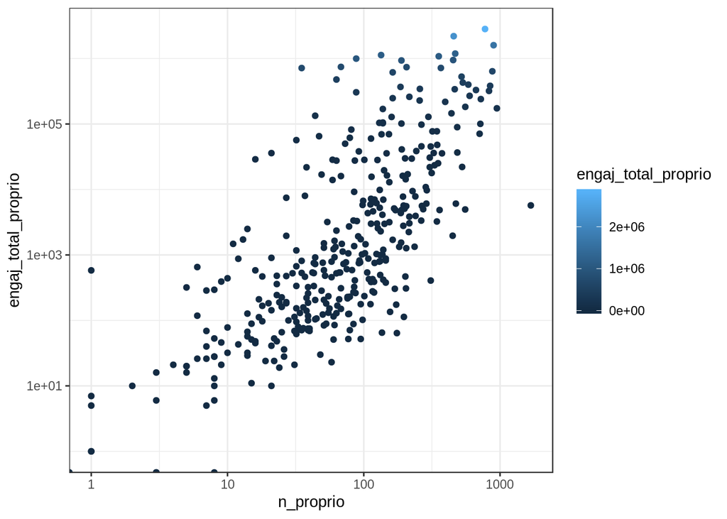

```r
atividade %>%
  na.omit(atividade)%>%
  ggplot(aes(x=n_proprio, y=engaj_total_proprio, color=engaj_total_proprio))+
  geom_point()+
  scale_x_log10()+
  scale_y_log10()
```

```r
atividade %>%
  na.omit(atividade)%>%
  summarise(correlacao = cor(n_proprio, engaj_total_proprio, method = "pearson"),
            spearman = cor(n_proprio, engaj_total_proprio, method = "spearman"),
            kendall = cor(n_proprio, engaj_total_proprio, method = "kendall"))
```

| correlacao | spearman | kendall |
| --- | --- | --- |
| 0.422698 | 0.7448931 | 0.5634754 |

Semelhantemente a questão anterior pelo gráfico tem-se uma impressão de que existe sim uma relação entre o número de conteúdo próprio produzido pelo parlamentar e o e o engajamento total em conteúdo próprio. Visualmente falando, pode-se concluir que quanto mais conteúdo próprio é produzido, maior será o engajamento, maior será o núemro de reações no conteúdo próprio. O que é algo realmente esperado, quanto mais eu produzo existe a esperança de que mais engajamento seja gerado. Ao analisarmos os coeficientes de correlação encontramos os seguintes resultados

- Coef. de Pearson: Como o valor está entre 0,3-0,5, por convenção temos uma correlação fraca para este coeficiente.
- Coef. Spearman: A correlação de Spearman avalia a relação monotônica entre duas variáveis contínuas ou ordinais e geralmente as variáveis tendem a mudar juntas mas não necessariamente a uma taxa constante. Para este caso temos um valor de correlação bastante considerável, indicado que existe sim uma correlação.
- Coef. Kendall: O coeficiente de concordância de Kendall pode variar de 0 a 1. Quanto maior o valor de Kendall, mais forte é a concordância. Para o caso em questão, temos um valor acima da metade do espectro de avaliação, o que fortalece a ideia de que existe uma correlação entre as variáveis.

Dessa forma, podemos concluir que o número de conteúdo próprio tem um certo impacto no número de engajamento total próprio.